# FINTECH Final Project - Bank Marketing Classification

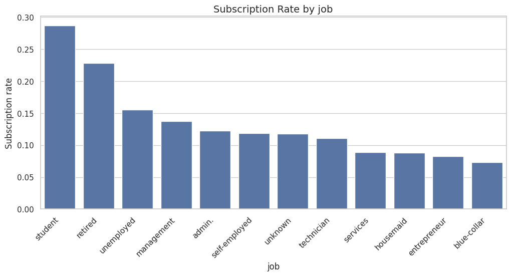

| job | subscription_rate | count |
| --- | --- | --- |
| student | 0.286780 | 938 |
| retired | 0.227915 | 2264 |
| unemployed | 0.155027 | 1303 |
| management | 0.137556 | 9458 |
| admin. | 0.122027 | 5171 |
| self-employed | 0.118429 | 1579 |
| unknown | 0.118056 | 288 |
| technician | 0.110570 | 7597 |
| services | 0.088830 | 4154 |
| housemaid | 0.087903 | 1240 |
| entrepreneur | 0.082717 | 1487 |
| blue-collar | 0.072750 | 9732 |

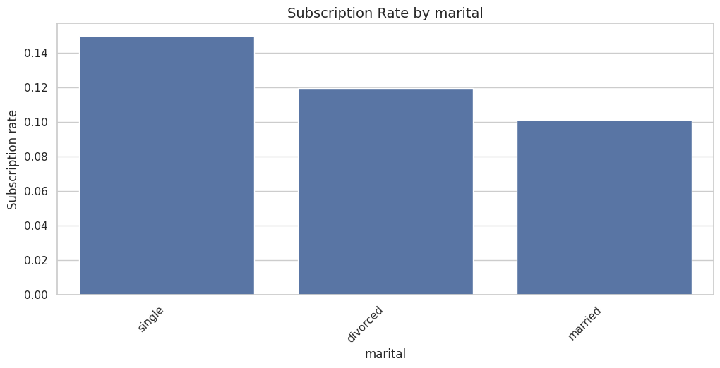

| marital | subscription_rate | count |
| --- | --- | --- |
| single | 0.149492 | 12790 |
| divorced | 0.119455 | 5207 |
| married | 0.101235 | 27214 |

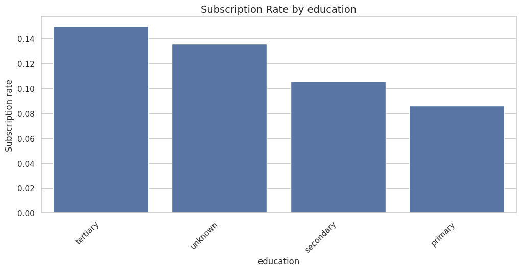

| education | subscription_rate | count |
| --- | --- | --- |
| tertiary | 0.150064 | 13301 |
| unknown | 0.135703 | 1857 |
| secondary | 0.105594 | 23202 |
| primary | 0.086265 | 6851 |

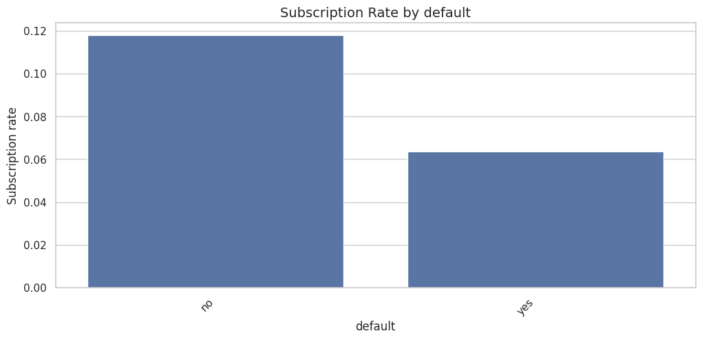

| default | subscription_rate | count |
| --- | --- | --- |
| no | 0.117961 | 44396 |
| yes | 0.063804 | 815 |

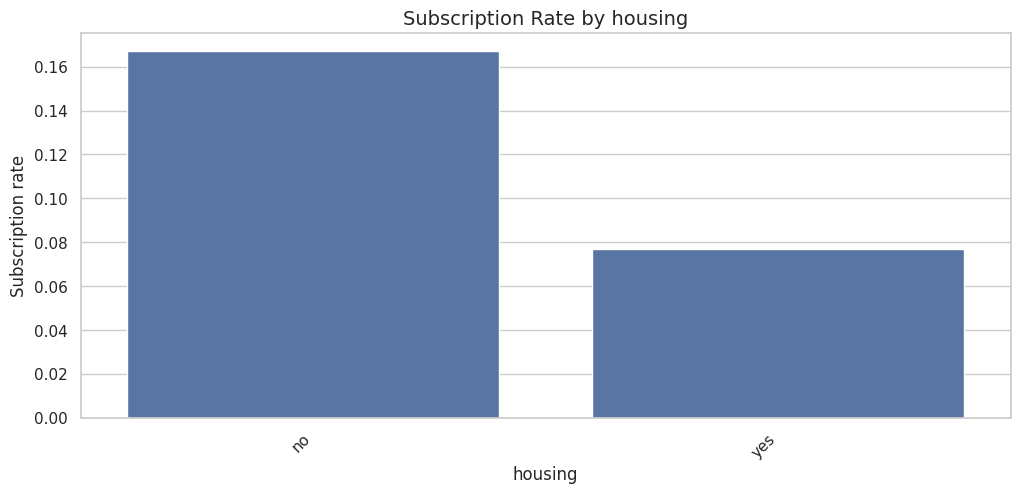

| housing | subscription_rate | count |
| --- | --- | --- |
| no | 0.167024 | 20081 |
| yes | 0.077000 | 25130 |

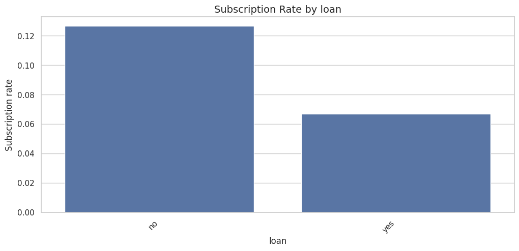

| loan | subscription_rate | count |
| --- | --- | --- |
| no | 0.126557 | 37967 |
| yes | 0.066814 | 7244 |

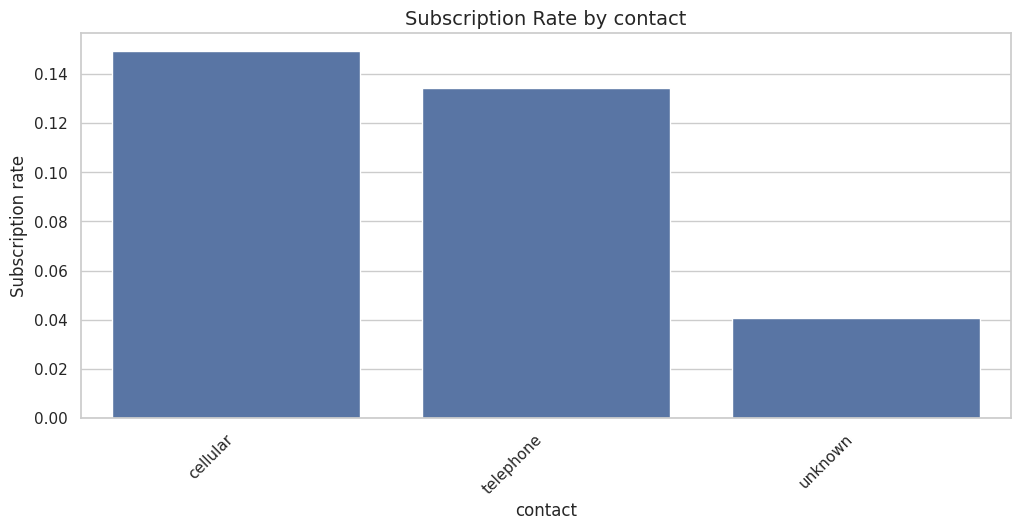

| contact | subscription_rate | count |
| --- | --- | --- |
| cellular | 0.149189 | 29285 |
| telephone | 0.134205 | 2906 |
| unknown | 0.040707 | 13020 |

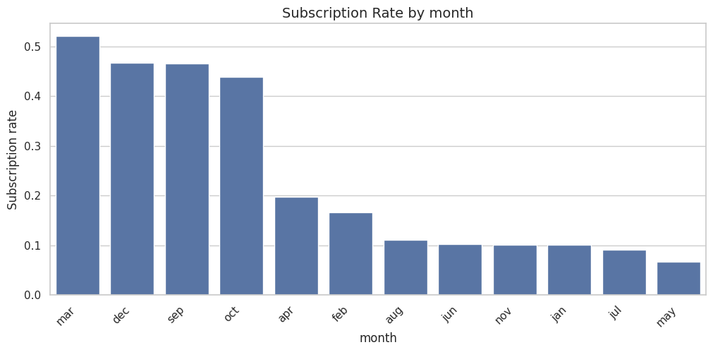

| month | subscription_rate | count |
| --- | --- | --- |
| mar | 0.519916 | 477 |
| dec | 0.467290 | 214 |
| sep | 0.464594 | 579 |
| oct | 0.437669 | 738 |
| apr | 0.196794 | 2932 |
| feb | 0.166478 | 2649 |
| aug | 0.110133 | 6247 |
| jun | 0.102228 | 5341 |
| nov | 0.101511 | 3970 |
| jan | 0.101212 | 1403 |
| jul | 0.090935 | 6895 |
| may | 0.067195 | 13766 |

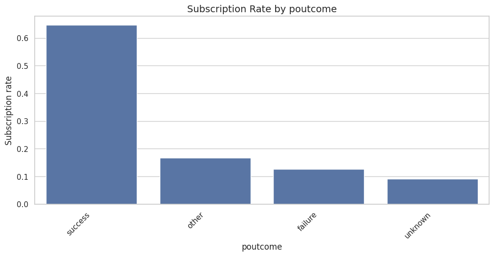

| poutcome | subscription_rate | count |
| --- | --- | --- |
| success | 0.647253 | 1511 |
| other | 0.166848 | 1840 |
| failure | 0.126097 | 4901 |
| unknown | 0.091615 | 36959 |

```python
for col in cat_cols:
    plot_subscription_rate_by_category(df, col)
```

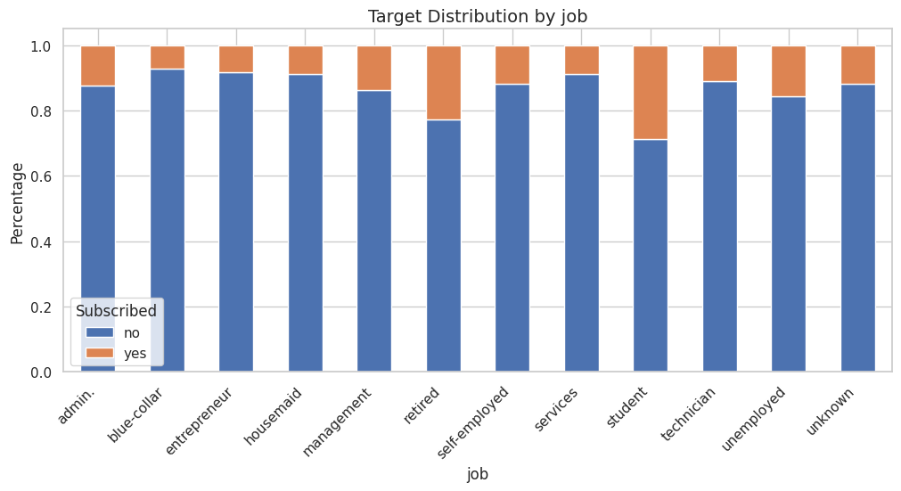

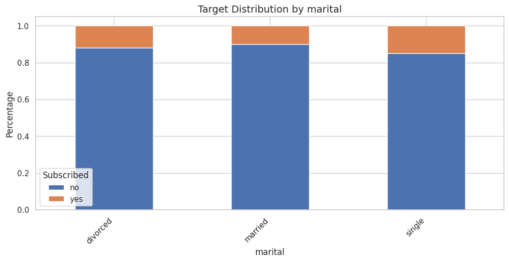

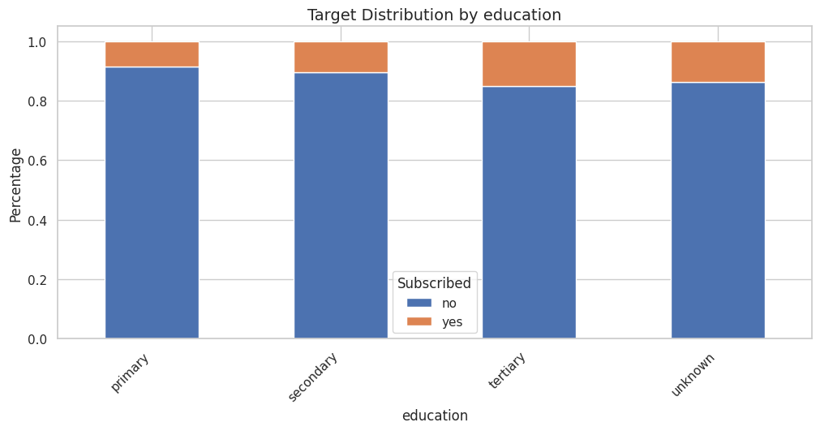

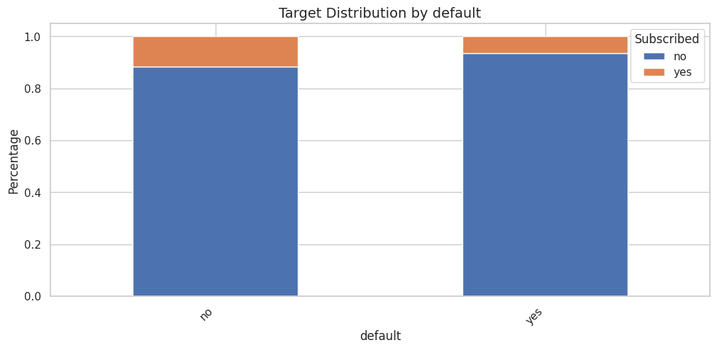

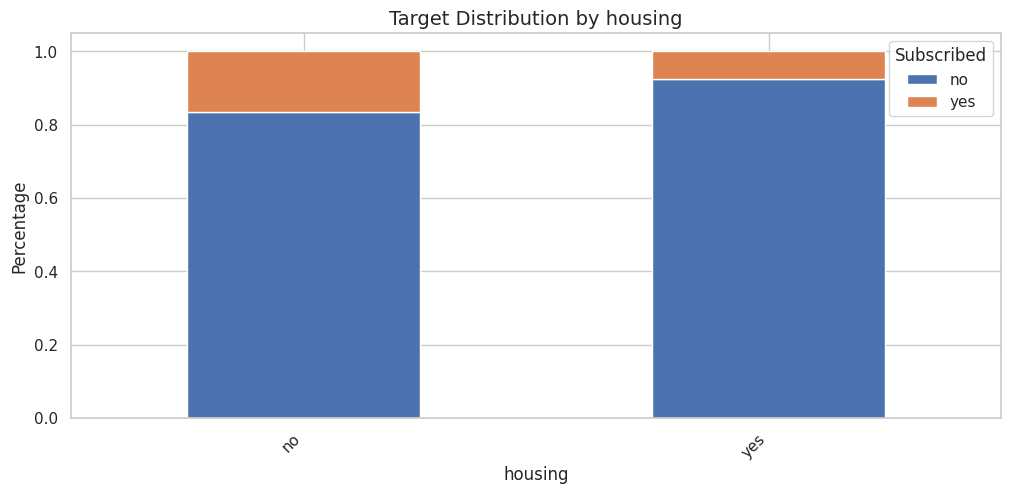

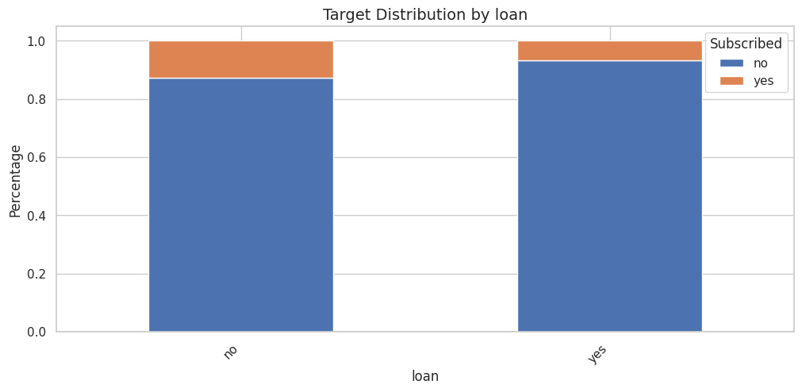

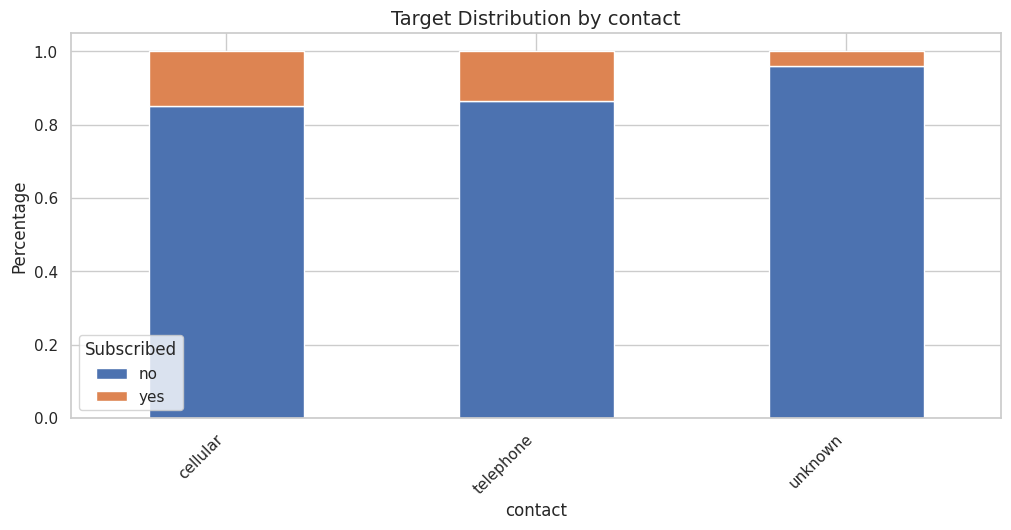

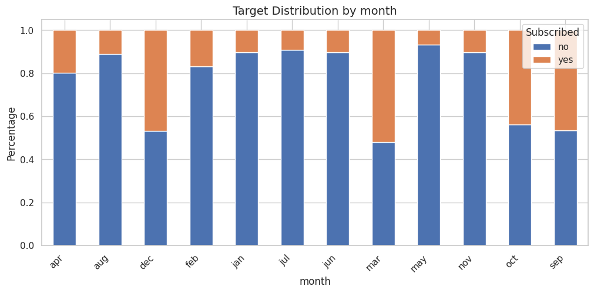

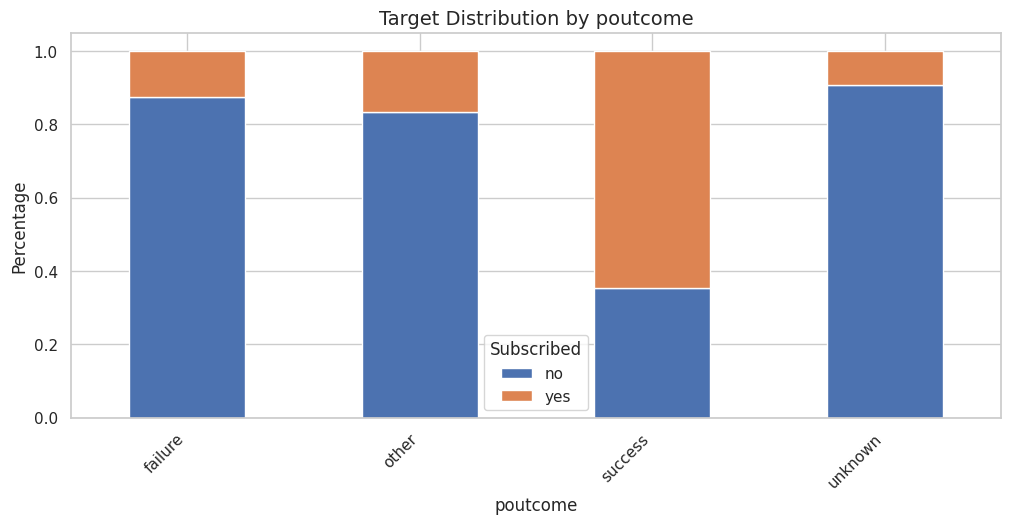

```python
for col in cat_cols:
    crosstab = pd.crosstab(df[col], df["y"], normalize="index")

    crosstab.plot(kind="bar", stacked=True, figsize=(12, 5))
    plt.title(f"Target Distribution by {col}")
    plt.ylabel("Percentage")
    plt.xlabel(col)
    plt.xticks(rotation=45, ha="right")
    plt.legend(title="Subscribed")
    plt.show()
```

### Categorical interpretation

The categorical analysis shows that subscription behavior may vary across customer groups and campaign characteristics. Variables such as job, education, contact type, month, and previous campaign outcome can help explain differences in subscription probability.

The `unknown` category is monitored rather than removed, because it may represent a meaningful lack of information instead of random noise.

## 9. Correlation analysis for numerical variables

We compute correlations between numerical variables and with the numeric target.

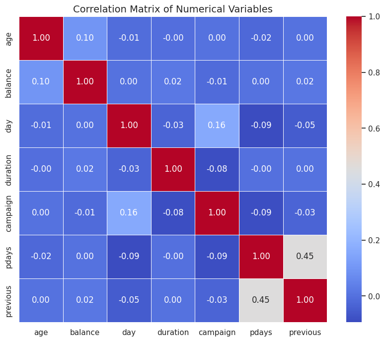

```python
# ============================================================
# 9. CORRELATION ANALYSIS
# ============================================================

corr = df[num_cols].corr()

plt.figure(figsize=(10, 8))
sns.heatmap(corr, annot=True, cmap="coolwarm", fmt=".2f", linewidths=0.5)
plt.title("Correlation Matrix of Numerical Variables")
plt.show()
```

```python
df_numeric_target = df.copy()
df_numeric_target["target_binary"] = df_numeric_target["y"].map({"no": 0, "yes": 1})

corr_target = (
    df_numeric_target[num_cols + ["target_binary"]]
    .corr()["target_binary"]
    .drop("target_binary")
    .sort_values(ascending=False)
)

display(corr_target.to_frame("correlation_with_target"))
```

|  | correlation_with_target |
| --- | --- |
| duration | 0.394521 |
| pdays | 0.103621 |
| previous | 0.093236 |
| balance | 0.052838 |
| age | 0.025155 |
| day | -0.028348 |
| campaign | -0.073172 |

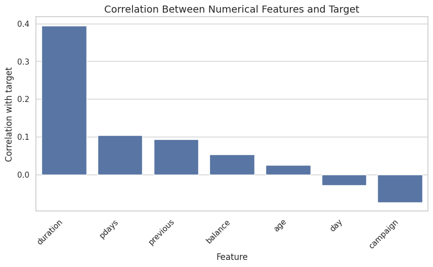

```python
plt.figure(figsize=(10, 5))
sns.barplot(x=corr_target.index, y=corr_target.values)
plt.title("Correlation Between Numerical Features and Target")
plt.ylabel("Correlation with target")
plt.xlabel("Feature")
plt.xticks(rotation=45, ha="right")
plt.show()
```

## 10. Business-oriented EDA

This section creates business-readable views:

- subscription rate by month
- subscription rate by contact type and month
- subscription rate by previous campaign outcome
- subscription rate by number of contacts

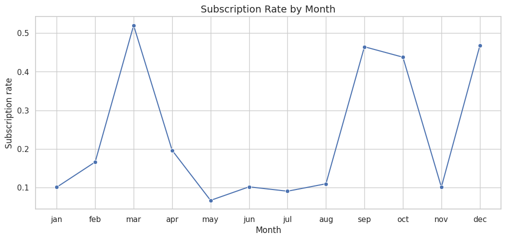

| month | subscription_rate |
| --- | --- |
| jan | 0.101212 |
| feb | 0.166478 |
| mar | 0.519916 |
| apr | 0.196794 |
| may | 0.067195 |
| jun | 0.102228 |
| jul | 0.090935 |
| aug | 0.110133 |
| sep | 0.464594 |
| oct | 0.437669 |
| nov | 0.101511 |
| dec | 0.467290 |

```python
# ============================================================
# 10. BUSINESS-ORIENTED EDA
# ============================================================

month_order = ["jan", "feb", "mar", "apr", "may", "jun", "jul", "aug", "sep", "oct", "nov", "dec"]

if "month" in df.columns:
    month_rate = (
        df.assign(target_binary=df["y"].map({"no": 0, "yes": 1}))
        .groupby("month")["target_binary"]
        .mean()
        .reindex(month_order)
    )

    plt.figure(figsize=(12, 5))
    sns.lineplot(x=month_rate.index, y=month_rate.values, marker="o")
    plt.title("Subscription Rate by Month")
    plt.ylabel("Subscription rate")
    plt.xlabel("Month")
    plt.show()

    display(month_rate.to_frame("subscription_rate"))
```

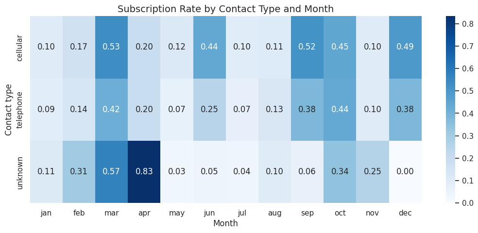

```python
if "month" in df.columns and "contact" in df.columns:
    heatmap_data = (
        df.assign(target_binary=df["y"].map({"no": 0, "yes": 1}))
        .pivot_table(index="contact", columns="month", values="target_binary", aggfunc="mean")
        .reindex(columns=month_order)
    )

    plt.figure(figsize=(13, 5))
    sns.heatmap(heatmap_data, annot=True, fmt=".2f", cmap="Blues")
    plt.title("Subscription Rate by Contact Type and Month")
    plt.xlabel("Month")
    plt.ylabel("Contact type")
    plt.show()
```

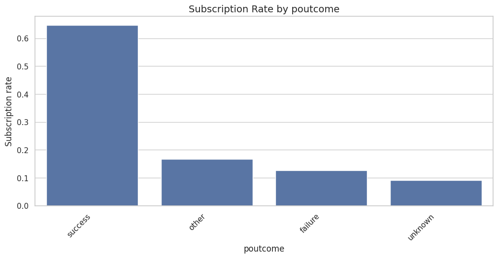

| poutcome | subscription_rate | count |
| --- | --- | --- |
| success | 0.647253 | 1511 |
| other | 0.166848 | 1840 |
| failure | 0.126097 | 4901 |
| unknown | 0.091615 | 36959 |

```python
if "poutcome" in df.columns:
    plot_subscription_rate_by_category(df, "poutcome")
```

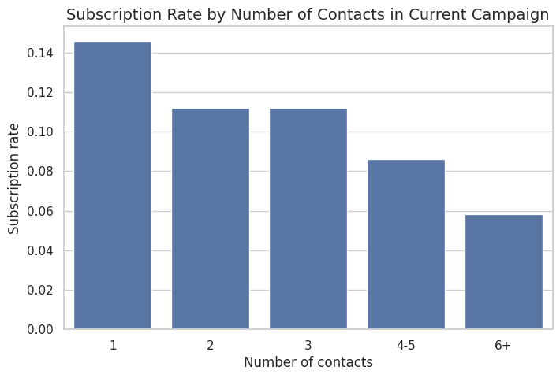

| campaign_bucket | subscription_rate |
| --- | --- |
| 1 | 0.145976 |
| 2 | 0.112035 |
| 3 | 0.111936 |
| 4-5 | 0.086266 |
| 6+ | 0.058094 |

```python
if "campaign" in df.columns:
    temp = df.copy()
    temp["campaign_bucket"] = pd.cut(
        temp["campaign"],
        bins=[0, 1, 2, 3, 5, np.inf],
        labels=["1", "2", "3", "4-5", "6+"]
    )

    campaign_rate = (
        temp.assign(target_binary=temp["y"].map({"no": 0, "yes": 1}))
        .groupby("campaign_bucket")["target_binary"]
        .mean()
    )

    plt.figure(figsize=(8, 5))
    sns.barplot(x=campaign_rate.index, y=campaign_rate.values)
    plt.title("Subscription Rate by Number of Contacts in Current Campaign")
    plt.xlabel("Number of contacts")
    plt.ylabel("Subscription rate")
    plt.show()

    display(campaign_rate.to_frame("subscription_rate"))
```

## EDA summary

The exploratory analysis shows that the subscription outcome is imbalanced, with a much larger number of non-subscribers than subscribers. This motivates the use of evaluation metrics beyond accuracy.

Both numerical and categorical variables contain useful predictive information. Numerical variables help capture customer and campaign intensity, while categorical variables describe customer profiles, contact channels, campaign timing, and previous campaign outcomes.

The variable `duration` is especially important from a methodological perspective. It is highly predictive, but it is only known after the call takes place. For this reason, the final analysis also includes a robustness check without `duration`.

# 11. Data preprocessing

We now prepare the data for modeling.

Steps:

1. Encode target variable
2. Split into training, validation and test sets
3. Define preprocessing pipelines

We use a 60/20/20 split:

- training set: model fitting
- validation set: model selection and tuning
- test set: final unbiased evaluation

```python
# ============================================================
# 11. DATA PREPROCESSING
# ============================================================

X = df.drop(columns=["y"])
y = df["y"].map({"no": 0, "yes": 1})

num_features = X.select_dtypes(include=np.number).columns.tolist()
cat_features = X.select_dtypes(include="object").columns.tolist()

print("Numerical features:", num_features)
print("Categorical features:", cat_features)
```

```
Numerical features: ['age', 'balance', 'day', 'duration', 'campaign', 'pdays', 'previous']
Categorical features: ['job', 'marital', 'education', 'default', 'housing', 'loan', 'contact', 'month', 'poutcome']
```

```python
X_train, X_temp, y_train, y_temp = train_test_split(
    X, y,
    test_size=0.40,
    stratify=y,
    random_state=RANDOM_STATE
)

X_val, X_test, y_val, y_test = train_test_split(
    X_temp, y_temp,
    test_size=0.50,
    stratify=y_temp,
    random_state=RANDOM_STATE
)

print("Training set:", X_train.shape)
print("Validation set:", X_val.shape)
print("Test set:", X_test.shape)

print("\nTarget positive rate in each set:")
print("Train:", y_train.mean().round(4))
print("Validation:", y_val.mean().round(4))
print("Test:", y_test.mean().round(4))
```

```
Training set: (27126, 16)
Validation set: (9042, 16)
Test set: (9043, 16)

Target positive rate in each set:
Train: 0.117
Validation: 0.117
Test: 0.117
```

```python
logistic_preprocessor = ColumnTransformer(
    transformers=[
        ("num", StandardScaler(), num_features),
        ("cat", OneHotEncoder(handle_unknown="ignore"), cat_features)
    ]
)

rf_preprocessor = ColumnTransformer(
    transformers=[
        ("num", "passthrough", num_features),
        ("cat", OneHotEncoder(handle_unknown="ignore"), cat_features)
    ]
)
```

# 12. Evaluation functions

Because this is a binary classification problem and the target may be imbalanced, we evaluate:

- Accuracy
- Balanced Accuracy
- Precision
- Recall
- F1-score
- ROC-AUC
- PR-AUC

```python
# ============================================================
# 12. EVALUATION FUNCTIONS
# ============================================================

def evaluate_model(model, X_data, y_data, model_name="Model", threshold=0.5):
    y_proba = model.predict_proba(X_data)[:, 1]
    y_pred = (y_proba >= threshold).astype(int)

    metrics = {
        "model": model_name,
        "threshold": threshold,
        "accuracy": accuracy_score(y_data, y_pred),
        "balanced_accuracy": balanced_accuracy_score(y_data, y_pred),
        "precision": precision_score(y_data, y_pred, zero_division=0),
        "recall": recall_score(y_data, y_pred, zero_division=0),
        "f1": f1_score(y_data, y_pred, zero_division=0),
        "roc_auc": roc_auc_score(y_data, y_proba),
        "pr_auc": average_precision_score(y_data, y_proba)
    }

    return metrics


def plot_confusion_matrix(model, X_data, y_data, threshold=0.5, title="Confusion Matrix"):
    y_proba = model.predict_proba(X_data)[:, 1]
    y_pred = (y_proba >= threshold).astype(int)
    cm = confusion_matrix(y_data, y_pred)

    plt.figure(figsize=(6, 5))
    sns.heatmap(cm, annot=True, fmt="d", cmap="Blues")
    plt.title(title)
    plt.xlabel("Predicted")
    plt.ylabel("Actual")
    plt.show()


def print_classification_report(model, X_data, y_data, threshold=0.5):
    y_proba = model.predict_proba(X_data)[:, 1]
    y_pred = (y_proba >= threshold).astype(int)
    print(classification_report(y_data, y_pred, target_names=["no", "yes"]))
```

# 13. Baseline model

Before training real ML models, we create a naive baseline.

This answers:

> Do our ML models actually improve over a trivial prediction rule?

```python
# ============================================================
# 13. BASELINE MODEL
# ============================================================

baseline_model = DummyClassifier(strategy="most_frequent")

baseline_pipeline = Pipeline(steps=[
    ("preprocessor", rf_preprocessor),
    ("model", baseline_model)
])

baseline_pipeline.fit(X_train, y_train)

baseline_val_metrics = evaluate_model(
    baseline_pipeline,
    X_val,
    y_val,
    model_name="Baseline - Most Frequent"
)

display(pd.DataFrame([baseline_val_metrics]))
```

|  | model | threshold | accuracy | balanced_accuracy | precision | recall | f1 | roc_auc | pr_auc |
| --- | --- | --- | --- | --- | --- | --- | --- | --- | --- |
| 0 | Baseline - Most Frequent | 0.5 | 0.88299 | 0.5 | 0.0 | 0.0 | 0.0 | 0.5 | 0.11701 |

# 14. Model 1 - Logistic Regression

Logistic Regression is used because it is:

- simple
- interpretable
- a strong baseline for binary classification
- useful for understanding linear effects

We use `class_weight="balanced"` to compensate for possible class imbalance.

```python
# ============================================================
# 14. LOGISTIC REGRESSION
# ============================================================

logistic_model = LogisticRegression(
    max_iter=2000,
    class_weight="balanced",
    random_state=RANDOM_STATE
)

logistic_pipeline = Pipeline(steps=[
    ("preprocessor", logistic_preprocessor),
    ("model", logistic_model)
])

logistic_pipeline.fit(X_train, y_train)

logistic_val_metrics = evaluate_model(
    logistic_pipeline,
    X_val,
    y_val,
    model_name="Logistic Regression"
)

display(pd.DataFrame([logistic_val_metrics]))
```

|  | model | threshold | accuracy | balanced_accuracy | precision | recall | f1 | roc_auc | pr_auc |
| --- | --- | --- | --- | --- | --- | --- | --- | --- | --- |
| 0 | Logistic Regression | 0.5 | 0.843508 | 0.831852 | 0.414388 | 0.816635 | 0.549793 | 0.907283 | 0.543847 |

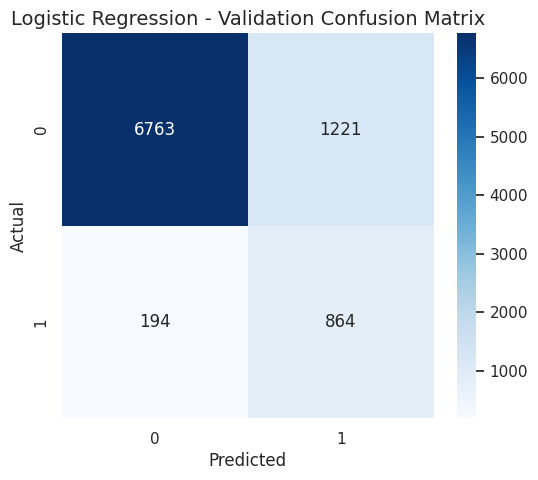

```
              precision    recall  f1-score   support

          no       0.97      0.85      0.91      7984
         yes       0.41      0.82      0.55      1058

    accuracy                           0.84      9042
   macro avg       0.69      0.83      0.73      9042
weighted avg       0.91      0.84      0.86      9042
```

```python
plot_confusion_matrix(
    logistic_pipeline,
    X_val,
    y_val,
    title="Logistic Regression - Validation Confusion Matrix"
)

print_classification_report(logistic_pipeline, X_val, y_val)
```

# 15. Model 2 - Random Forest

Random Forest is used because it can capture:

- non-linear relationships
- interactions between variables
- complex customer behavior

It is an ensemble of decision trees and is often effective on tabular data.

```python
# ============================================================
# 15. RANDOM FOREST
# ============================================================

rf_model = RandomForestClassifier(
    n_estimators=300,
    max_depth=None,
    min_samples_leaf=2,
    class_weight="balanced",
    random_state=RANDOM_STATE,
    n_jobs=-1
)

rf_pipeline = Pipeline(steps=[
    ("preprocessor", rf_preprocessor),
    ("model", rf_model)
])

rf_pipeline.fit(X_train, y_train)

rf_val_metrics = evaluate_model(
    rf_pipeline,
    X_val,
    y_val,
    model_name="Random Forest"
)

display(pd.DataFrame([rf_val_metrics]))
```

|  | model | threshold | accuracy | balanced_accuracy | precision | recall | f1 | roc_auc | pr_auc |
| --- | --- | --- | --- | --- | --- | --- | --- | --- | --- |
| 0 | Random Forest | 0.5 | 0.902676 | 0.775574 | 0.580036 | 0.609641 | 0.59447 | 0.928743 | 0.614651 |

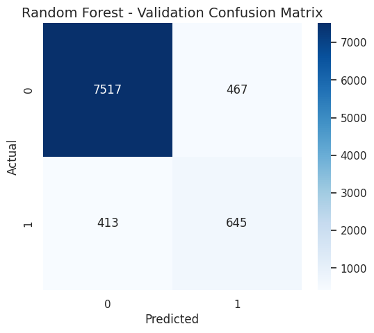

```
              precision    recall  f1-score   support

          no       0.95      0.94      0.94      7984
         yes       0.58      0.61      0.59      1058

    accuracy                           0.90      9042
   macro avg       0.76      0.78      0.77      9042
weighted avg       0.90      0.90      0.90      9042
```

```python
plot_confusion_matrix(
    rf_pipeline,
    X_val,
    y_val,
    title="Random Forest - Validation Confusion Matrix"
)

print_classification_report(rf_pipeline, X_val, y_val)
```

# 16. Model comparison on validation set

The preferred model should not be selected only by accuracy, especially if the target is imbalanced.

```python
# ============================================================
# 16. MODEL COMPARISON
# ============================================================

comparison_val = pd.DataFrame([
    baseline_val_metrics,
    logistic_val_metrics,
    rf_val_metrics
])

display(comparison_val.sort_values("roc_auc", ascending=False))
```

|  | model | threshold | accuracy | balanced_accuracy | precision | recall | f1 | roc_auc | pr_auc |
| --- | --- | --- | --- | --- | --- | --- | --- | --- | --- |
| 2 | Random Forest | 0.5 | 0.902676 | 0.775574 | 0.580036 | 0.609641 | 0.594470 | 0.928743 | 0.614651 |
| 1 | Logistic Regression | 0.5 | 0.843508 | 0.831852 | 0.414388 | 0.816635 | 0.549793 | 0.907283 | 0.543847 |
| 0 | Baseline - Most Frequent | 0.5 | 0.882990 | 0.500000 | 0.000000 | 0.000000 | 0.000000 | 0.500000 | 0.117010 |

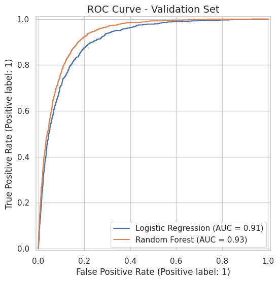

```python
plt.figure(figsize=(8, 6))

for model, name in [
    (logistic_pipeline, "Logistic Regression"),
    (rf_pipeline, "Random Forest")
]:
    RocCurveDisplay.from_estimator(model, X_val, y_val, name=name, ax=plt.gca())

plt.title("ROC Curve - Validation Set")
plt.show()
```

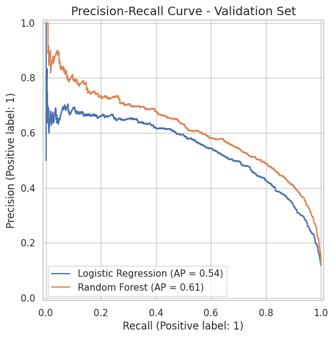

```python
plt.figure(figsize=(8, 6))

for model, name in [
    (logistic_pipeline, "Logistic Regression"),
    (rf_pipeline, "Random Forest")
]:
    PrecisionRecallDisplay.from_estimator(model, X_val, y_val, name=name, ax=plt.gca())

plt.title("Precision-Recall Curve - Validation Set")
plt.show()
```

### Model comparison interpretation

Logistic Regression provides a transparent benchmark for the classification task, while Random Forest can capture nonlinear relationships and interactions between predictors.

The preferred model is selected using validation performance rather than test performance. Since the target is imbalanced, the comparison focuses on ROC-AUC, PR-AUC, precision, recall, F1-score and balanced accuracy instead of relying only on accuracy.

In this analysis, Random Forest is preferred because it achieves the strongest validation ROC-AUC and PR-AUC among the compared models. This means that it ranks potential subscribers better overall and performs better on the minority positive class than the Logistic Regression benchmark.

# 17. Hyperparameter tuning for Random Forest

We tune the Random Forest to improve generalization and reduce overfitting.

```python
# ============================================================
# 17. RANDOM FOREST HYPERPARAMETER TUNING
# ============================================================

param_grid = {
    "model__n_estimators": [200, 300, 500],
    "model__max_depth": [None, 5, 10, 15],
    "model__min_samples_leaf": [1, 2, 5, 10],
    "model__max_features": ["sqrt", "log2"]
}

rf_grid = GridSearchCV(
    estimator=rf_pipeline,
    param_grid=param_grid,
    scoring="roc_auc",
    cv=3,
    n_jobs=-1,
    verbose=1
)

rf_grid.fit(X_train, y_train)

print("Best parameters:")
print(rf_grid.best_params_)

print("\nBest cross-validation ROC-AUC:")
print(rf_grid.best_score_)
```

```
Fitting 3 folds for each of 96 candidates, totalling 288 fits
Best parameters:
{'model__max_depth': None, 'model__max_features': 'sqrt', 'model__min_samples_leaf': 2, 'model__n_estimators': 500}

Best cross-validation ROC-AUC:
0.9288680681607758
```

```python
best_rf_pipeline = rf_grid.best_estimator_

best_rf_val_metrics = evaluate_model(
    best_rf_pipeline,
    X_val,
    y_val,
    model_name="Random Forest - Tuned"
)

display(pd.DataFrame([rf_val_metrics, best_rf_val_metrics]))
```

|  | model | threshold | accuracy | balanced_accuracy | precision | recall | f1 | roc_auc | pr_auc |
| --- | --- | --- | --- | --- | --- | --- | --- | --- | --- |
| 0 | Random Forest | 0.5 | 0.902676 | 0.775574 | 0.580036 | 0.609641 | 0.594470 | 0.928743 | 0.614651 |
| 1 | Random Forest - Tuned | 0.5 | 0.903119 | 0.774185 | 0.582727 | 0.605860 | 0.594069 | 0.929180 | 0.615243 |

# 18. Threshold analysis

The default threshold is 0.5.  
In marketing, the threshold can be adjusted depending on business goals:

- lower threshold: contact more clients, higher recall
- higher threshold: contact fewer clients, higher precision

```python
# ============================================================
# 18. THRESHOLD ANALYSIS
# ============================================================

def threshold_metrics(model, X_data, y_data, thresholds=np.arange(0.1, 0.91, 0.05)):
    rows = []
    y_proba = model.predict_proba(X_data)[:, 1]

    for threshold in thresholds:
        y_pred = (y_proba >= threshold).astype(int)
        rows.append({
            "threshold": threshold,
            "accuracy": accuracy_score(y_data, y_pred),
            "precision": precision_score(y_data, y_pred, zero_division=0),
            "recall": recall_score(y_data, y_pred, zero_division=0),
            "f1": f1_score(y_data, y_pred, zero_division=0),
            "contact_rate": y_pred.mean()
        })

    return pd.DataFrame(rows)

threshold_df = threshold_metrics(best_rf_pipeline, X_val, y_val)
display(threshold_df)
```

|  | threshold | accuracy | precision | recall | f1 | contact_rate |
| --- | --- | --- | --- | --- | --- | --- |
| 0 | 0.10 | 0.727715 | 0.296522 | 0.966919 | 0.453860 | 0.381553 |
| 1 | 0.15 | 0.783455 | 0.345254 | 0.948960 | 0.506304 | 0.321610 |
| 2 | 0.20 | 0.813758 | 0.378399 | 0.920605 | 0.536344 | 0.284672 |
| 3 | 0.25 | 0.837978 | 0.411252 | 0.891304 | 0.562817 | 0.253594 |
| 4 | 0.30 | 0.858660 | 0.445759 | 0.854442 | 0.585872 | 0.224287 |
| 5 | 0.35 | 0.873590 | 0.476376 | 0.810019 | 0.599930 | 0.198960 |
| 6 | 0.40 | 0.887967 | 0.514507 | 0.754253 | 0.611729 | 0.171533 |
| 7 | 0.45 | 0.897810 | 0.550150 | 0.694707 | 0.614035 | 0.147755 |
| 8 | 0.50 | 0.903119 | 0.582727 | 0.605860 | 0.594069 | 0.121655 |
| 9 | 0.55 | 0.907764 | 0.625561 | 0.527410 | 0.572308 | 0.098651 |
| 10 | 0.60 | 0.907874 | 0.670713 | 0.417769 | 0.514851 | 0.072882 |
| 11 | 0.65 | 0.904114 | 0.695297 | 0.321361 | 0.439560 | 0.054081 |
| 12 | 0.70 | 0.900354 | 0.721127 | 0.241966 | 0.362350 | 0.039261 |
| 13 | 0.75 | 0.896041 | 0.752137 | 0.166352 | 0.272446 | 0.025879 |
| 14 | 0.80 | 0.892391 | 0.781457 | 0.111531 | 0.195203 | 0.016700 |
| 15 | 0.85 | 0.889184 | 0.818182 | 0.068053 | 0.125654 | 0.009732 |
| 16 | 0.90 | 0.885977 | 0.864865 | 0.030246 | 0.058447 | 0.004092 |

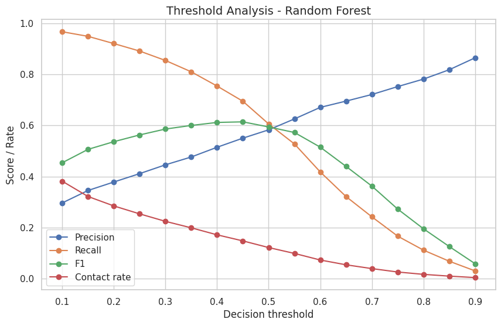

```python
plt.figure(figsize=(10, 6))
plt.plot(threshold_df["threshold"], threshold_df["precision"], marker="o", label="Precision")
plt.plot(threshold_df["threshold"], threshold_df["recall"], marker="o", label="Recall")
plt.plot(threshold_df["threshold"], threshold_df["f1"], marker="o", label="F1")
plt.plot(threshold_df["threshold"], threshold_df["contact_rate"], marker="o", label="Contact rate")
plt.title("Threshold Analysis - Random Forest")
plt.xlabel("Decision threshold")
plt.ylabel("Score / Rate")
plt.legend()
plt.show()
```

# 19. Final evaluation on test set

After selecting the preferred model using the validation set, we evaluate it once on the test set.

```python
# ============================================================
# 19. FINAL TEST EVALUATION
# ============================================================

preferred_model = best_rf_pipeline
preferred_model_name = "Random Forest - Tuned"

test_metrics = evaluate_model(
    preferred_model,
    X_test,
    y_test,
    model_name=preferred_model_name
)

display(pd.DataFrame([test_metrics]))
```

|  | model | threshold | accuracy | balanced_accuracy | precision | recall | f1 | roc_auc | pr_auc |
| --- | --- | --- | --- | --- | --- | --- | --- | --- | --- |
| 0 | Random Forest - Tuned | 0.5 | 0.90512 | 0.777366 | 0.591575 | 0.610586 | 0.60093 | 0.93278 | 0.633935 |

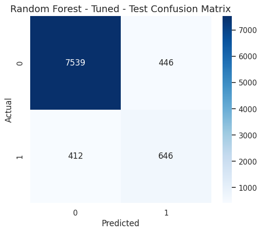

```
              precision    recall  f1-score   support

          no       0.95      0.94      0.95      7985
         yes       0.59      0.61      0.60      1058

    accuracy                           0.91      9043
   macro avg       0.77      0.78      0.77      9043
weighted avg       0.91      0.91      0.91      9043
```

```python
plot_confusion_matrix(
    preferred_model,
    X_test,
    y_test,
    title=f"{preferred_model_name} - Test Confusion Matrix"
)

print_classification_report(preferred_model, X_test, y_test)
```

# 20. Feature selection

The assignment asks to propose a strategy to decrease the number of features and study the impact.

We use Random Forest feature importance to select the most relevant original variables.

```python
# ============================================================
# 20. FEATURE IMPORTANCE AND FEATURE SELECTION
# ============================================================

def get_feature_names_from_preprocessor(preprocessor):
    output_features = []

    for name, transformer, columns in preprocessor.transformers_:
        if name == "remainder":
            continue

        if hasattr(transformer, "get_feature_names_out"):
            names = transformer.get_feature_names_out(columns)
        elif transformer == "passthrough":
            names = columns
        else:
            names = columns

        output_features.extend(names)

    return list(output_features)

preprocessor_fitted = preferred_model.named_steps["preprocessor"]
model_fitted = preferred_model.named_steps["model"]

encoded_feature_names = get_feature_names_from_preprocessor(preprocessor_fitted)

rf_importances = pd.DataFrame({
    "feature": encoded_feature_names,
    "importance": model_fitted.feature_importances_
}).sort_values("importance", ascending=False)

display(rf_importances.head(30))
```

|  | feature | importance |
| --- | --- | --- |
| 3 | duration | 0.371502 |
| 1 | balance | 0.068643 |
| 0 | age | 0.063962 |
| 2 | day | 0.057558 |
| 49 | poutcome_success | 0.039497 |
| 4 | campaign | 0.029781 |
| 5 | pdays | 0.028924 |
| 34 | contact_unknown | 0.028092 |
| 32 | contact_cellular | 0.020147 |
| 6 | previous | 0.018799 |
| 28 | housing_no | 0.018421 |
| 29 | housing_yes | 0.018064 |
| 43 | month_may | 0.013381 |
| 45 | month_oct | 0.012980 |
| 42 | month_mar | 0.012318 |
| 36 | month_aug | 0.011711 |
| 35 | month_apr | 0.011439 |
| 50 | poutcome_unknown | 0.011254 |
| 41 | month_jun | 0.009693 |
| 40 | month_jul | 0.009647 |
| 20 | marital_married | 0.008883 |
| 24 | education_tertiary | 0.008251 |
| 21 | marital_single | 0.007830 |
| 38 | month_feb | 0.007639 |
| 23 | education_secondary | 0.007576 |
| 44 | month_nov | 0.007175 |
| 8 | job_blue-collar | 0.007129 |
| 11 | job_management | 0.006842 |
| 16 | job_technician | 0.006748 |
| 31 | loan_yes | 0.006230 |

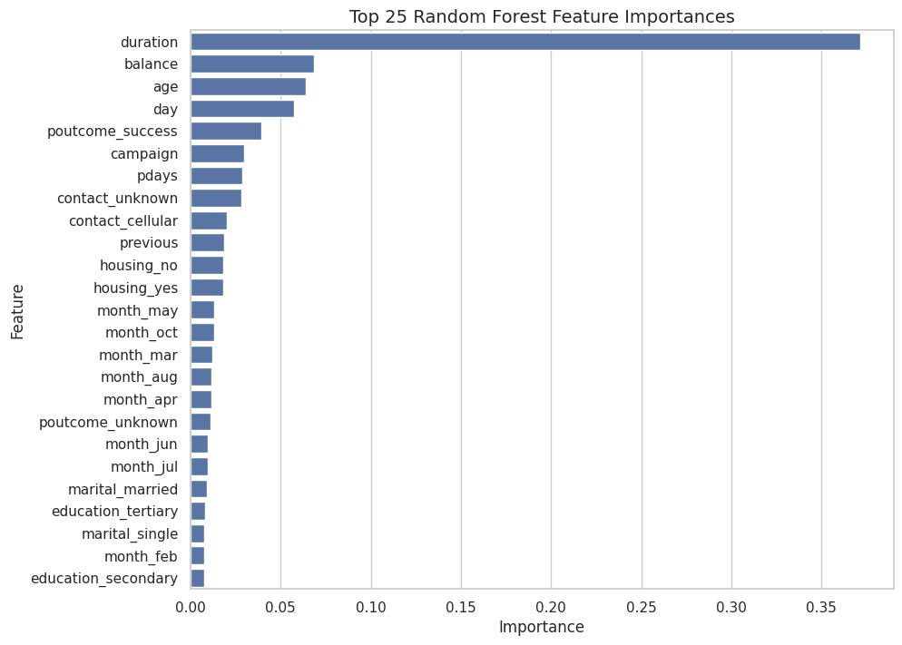

```python
plt.figure(figsize=(10, 8))
sns.barplot(
    data=rf_importances.head(25),
    x="importance",
    y="feature"
)
plt.title("Top 25 Random Forest Feature Importances")
plt.xlabel("Importance")
plt.ylabel("Feature")
plt.show()
```

```python
def map_encoded_to_original(encoded_feature, original_num_features, original_cat_features):
    if encoded_feature in original_num_features:
        return encoded_feature

    for cat in original_cat_features:
        if encoded_feature.startswith(cat + "_"):
            return cat

    return encoded_feature

rf_importances["original_feature"] = rf_importances["feature"].apply(
    lambda x: map_encoded_to_original(x, num_features, cat_features)
)

original_importance = (
    rf_importances.groupby("original_feature")["importance"]
    .sum()
    .sort_values(ascending=False)
    .reset_index()
)

display(original_importance)
```

|  | original_feature | importance |
| --- | --- | --- |
| 0 | duration | 0.371502 |
| 1 | month | 0.106615 |
| 2 | balance | 0.068643 |
| 3 | age | 0.063962 |
| 4 | poutcome | 0.059639 |
| 5 | day | 0.057558 |
| 6 | contact | 0.052440 |
| 7 | job | 0.047102 |
| 8 | housing | 0.036484 |
| 9 | campaign | 0.029781 |
| 10 | pdays | 0.028924 |
| 11 | education | 0.023541 |
| 12 | marital | 0.021185 |
| 13 | previous | 0.018799 |
| 14 | loan | 0.012402 |
| 15 | default | 0.001424 |

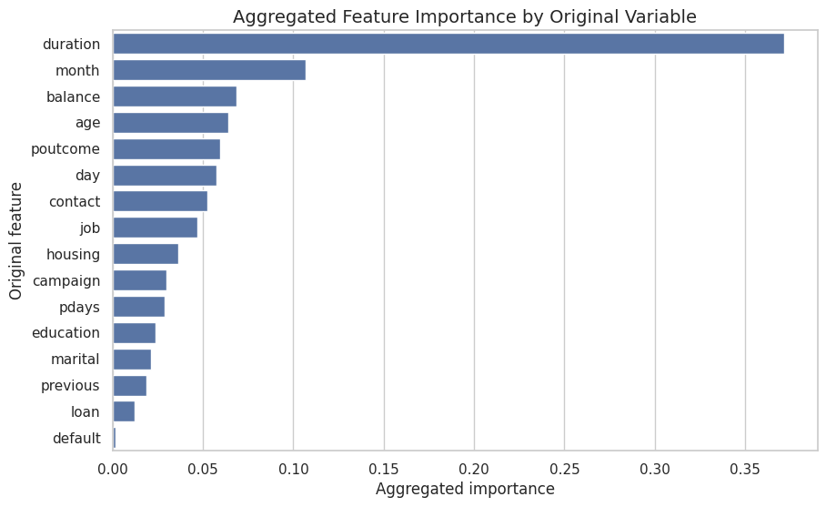

```python
plt.figure(figsize=(10, 6))
sns.barplot(
    data=original_importance,
    x="importance",
    y="original_feature"
)
plt.title("Aggregated Feature Importance by Original Variable")
plt.xlabel("Aggregated importance")
plt.ylabel("Original feature")
plt.show()
```

```python
TOP_K = 10

selected_features = original_importance["original_feature"].head(TOP_K).tolist()
print("Selected features:")
print(selected_features)
```

```
Selected features:
['duration', 'month', 'balance', 'age', 'poutcome', 'day', 'contact', 'job', 'housing', 'campaign']
```

## 21. Retrain model with selected features

We now retrain the preferred model using only selected features and compare performance.

```python
# ============================================================
# 21. RETRAIN WITH SELECTED FEATURES
# ============================================================

X_train_sel = X_train[selected_features]
X_val_sel = X_val[selected_features]
X_test_sel = X_test[selected_features]

num_features_sel = X_train_sel.select_dtypes(include=np.number).columns.tolist()
cat_features_sel = X_train_sel.select_dtypes(include="object").columns.tolist()

rf_preprocessor_sel = ColumnTransformer(
    transformers=[
        ("num", "passthrough", num_features_sel),
        ("cat", OneHotEncoder(handle_unknown="ignore"), cat_features_sel)
    ]
)

rf_selected_pipeline = Pipeline(steps=[
    ("preprocessor", rf_preprocessor_sel),
    ("model", RandomForestClassifier(
        n_estimators=300,
        max_depth=None,
        min_samples_leaf=2,
        class_weight="balanced",
        random_state=RANDOM_STATE,
        n_jobs=-1
    ))
])

rf_selected_pipeline.fit(X_train_sel, y_train)

rf_selected_val_metrics = evaluate_model(
    rf_selected_pipeline,
    X_val_sel,
    y_val,
    model_name=f"Random Forest - Top {TOP_K} Features"
)

feature_selection_comparison = pd.DataFrame([
    best_rf_val_metrics,
    rf_selected_val_metrics
])

display(feature_selection_comparison)
```

|  | model | threshold | accuracy | balanced_accuracy | precision | recall | f1 | roc_auc | pr_auc |
| --- | --- | --- | --- | --- | --- | --- | --- | --- | --- |
| 0 | Random Forest - Tuned | 0.5 | 0.903119 | 0.774185 | 0.582727 | 0.605860 | 0.594069 | 0.929180 | 0.615243 |
| 1 | Random Forest - Top 10 Features | 0.5 | 0.899690 | 0.792332 | 0.561432 | 0.652174 | 0.603411 | 0.929276 | 0.608523 |

```python
rf_selected_test_metrics = evaluate_model(
    rf_selected_pipeline,
    X_test_sel,
    y_test,
    model_name=f"Random Forest - Top {TOP_K} Features"
)

display(pd.DataFrame([test_metrics, rf_selected_test_metrics]))
```

|  | model | threshold | accuracy | balanced_accuracy | precision | recall | f1 | roc_auc | pr_auc |
| --- | --- | --- | --- | --- | --- | --- | --- | --- | --- |
| 0 | Random Forest - Tuned | 0.5 | 0.905120 | 0.777366 | 0.591575 | 0.610586 | 0.600930 | 0.932780 | 0.633935 |
| 1 | Random Forest - Top 10 Features | 0.5 | 0.905894 | 0.798713 | 0.587195 | 0.658790 | 0.620935 | 0.933525 | 0.634711 |

### Feature selection interpretation

Feature selection is based on the importance of the original variables in the Random Forest model. The selected subset keeps the strongest predictors and allows the model to be compared against the full-feature version.

If the reduced model obtains performance close to the full model, the smaller feature set is preferable from an interpretability and deployment perspective. If performance decreases substantially, the removed variables still contain useful predictive information.

# 22. Permutation importance

Permutation importance measures how much model performance decreases when each feature is randomly shuffled.

```python
# ============================================================
# 22. PERMUTATION IMPORTANCE
# ============================================================

perm_importance = permutation_importance(
    preferred_model,
    X_val,
    y_val,
    scoring="roc_auc",
    n_repeats=10,
    random_state=RANDOM_STATE,
    n_jobs=-1
)

perm_df = pd.DataFrame({
    "feature": X_val.columns,
    "importance_mean": perm_importance.importances_mean,
    "importance_std": perm_importance.importances_std
}).sort_values("importance_mean", ascending=False)

display(perm_df)
```

|  | feature | importance_mean | importance_std |
| --- | --- | --- | --- |
| 11 | duration | 0.199370 | 0.005497 |
| 10 | month | 0.050774 | 0.001399 |
| 8 | contact | 0.028332 | 0.002844 |
| 6 | housing | 0.013125 | 0.001650 |
| 15 | poutcome | 0.012885 | 0.000823 |
| 9 | day | 0.009952 | 0.000681 |
| 13 | pdays | 0.004479 | 0.000503 |
| 0 | age | 0.003372 | 0.000509 |
| 5 | balance | 0.003320 | 0.000953 |
| 7 | loan | 0.001835 | 0.000556 |
| 2 | marital | 0.001727 | 0.000494 |
| 12 | campaign | 0.001527 | 0.000486 |
| 14 | previous | 0.001403 | 0.000404 |
| 1 | job | 0.000817 | 0.000383 |
| 3 | education | 0.000426 | 0.000326 |
| 4 | default | -0.000023 | 0.000063 |

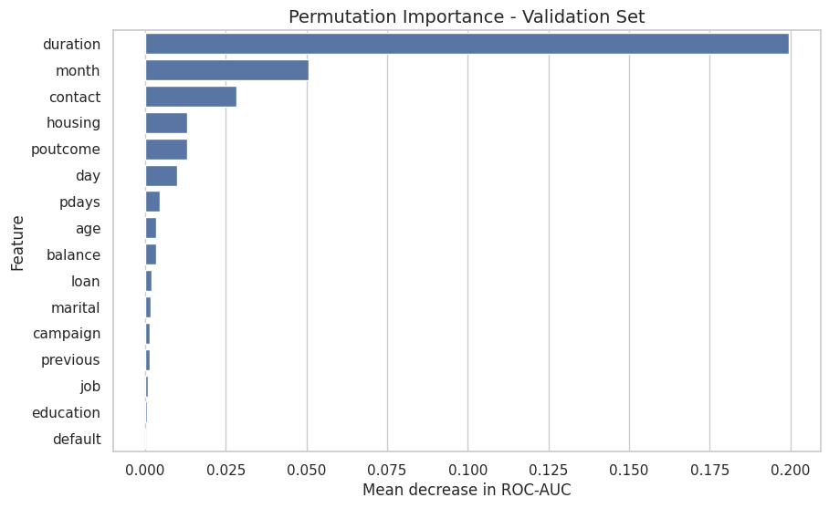

```python
plt.figure(figsize=(10, 6))
sns.barplot(
    data=perm_df,
    x="importance_mean",
    y="feature"
)
plt.title("Permutation Importance - Validation Set")
plt.xlabel("Mean decrease in ROC-AUC")
plt.ylabel("Feature")
plt.show()
```

# 23. SHAP interpretability

SHAP values explain how each feature contributes to model predictions.

They can be used for:

- global interpretability
- local interpretability

```python
# ============================================================
# 23. SHAP INTERPRETABILITY
# ============================================================

if not SHAP_AVAILABLE:
    print("SHAP is not available. Install it with: !pip install shap")

else:
    # Transform validation data using the preprocessing pipeline
    X_val_transformed = preferred_model.named_steps["preprocessor"].transform(X_val)

    # Convert sparse matrix to dense array if needed
    if hasattr(X_val_transformed, "toarray"):
        X_val_transformed = X_val_transformed.toarray()

    # Extract feature names after preprocessing / one-hot encoding
    feature_names = get_feature_names_from_preprocessor(
        preferred_model.named_steps["preprocessor"]
    )

    # Use a smaller random sample to make SHAP computation faster
    np.random.seed(42)
    sample_size = min(200, X_val_transformed.shape[0])
    idx = np.random.choice(X_val_transformed.shape[0], sample_size, replace=False)
    X_shap = X_val_transformed[idx]

    # Extract the Random Forest model from the pipeline
    rf_model_only = preferred_model.named_steps["model"]

    # Compute SHAP values
    explainer = shap.TreeExplainer(rf_model_only)
    shap_values = explainer.shap_values(X_shap)

    print("SHAP values computed successfully.")
    print("Sample size used for SHAP:", sample_size)
```

```
SHAP values computed successfully.
Sample size used for SHAP: 200
```

[figure not shown]

```python
if SHAP_AVAILABLE:
    if isinstance(shap_values, list):
        shap_to_plot = shap_values[1]
    else:
        shap_to_plot = shap_values

    shap.summary_plot(
        shap_to_plot,
        X_shap,
        feature_names=feature_names,
        max_display=20
    )
```

```
Observation index: 0
Predicted probability of subscription: 0.0559
Actual target: 0
```

[figure not shown]

```python
if SHAP_AVAILABLE:
    observation_index = 0

    predicted_probability = preferred_model.predict_proba(X_val.iloc[[observation_index]])[0, 1]
    actual_value = y_val.iloc[observation_index]

    print("Observation index:", observation_index)
    print("Predicted probability of subscription:", round(predicted_probability, 4))
    print("Actual target:", actual_value)

    # Fix: Ensure expected_value is a scalar for the positive class
    expected_value = explainer.expected_value[1]

    shap.force_plot(
        expected_value,
        shap_to_plot[observation_index][:, 1], # Select SHAP values for the positive class (index 1)
        X_shap[observation_index],
        feature_names=feature_names,
        matplotlib=True
    )
```

### SHAP interpretation

SHAP values are used to explain how individual features contribute to the Random Forest predictions. Positive SHAP values increase the predicted probability of subscription, while negative SHAP values decrease it.

# 24. Optional robustness check - model without `duration`

Since `duration` is known only after the phone call, we compare performance without it.

This is methodologically strong because it separates:

- prediction after the call
- pre-campaign targeting

```python
# ============================================================
# 24. OPTIONAL ROBUSTNESS CHECK WITHOUT DURATION
# ============================================================

if "duration" in X.columns:
    X_no_duration = X.drop(columns=["duration"])

    X_train_nd, X_temp_nd, y_train_nd, y_temp_nd = train_test_split(
        X_no_duration, y,
        test_size=0.40,
        stratify=y,
        random_state=RANDOM_STATE
    )

    X_val_nd, X_test_nd, y_val_nd, y_test_nd = train_test_split(
        X_temp_nd, y_temp_nd,
        test_size=0.50,
        stratify=y_temp_nd,
        random_state=RANDOM_STATE
    )

    num_nd = X_train_nd.select_dtypes(include=np.number).columns.tolist()
    cat_nd = X_train_nd.select_dtypes(include="object").columns.tolist()

    rf_preprocessor_nd = ColumnTransformer(
        transformers=[
            ("num", "passthrough", num_nd),
            ("cat", OneHotEncoder(handle_unknown="ignore"), cat_nd)
        ]
    )

    rf_no_duration_pipeline = Pipeline(steps=[
        ("preprocessor", rf_preprocessor_nd),
        ("model", RandomForestClassifier(
            n_estimators=300,
            min_samples_leaf=2,
            class_weight="balanced",
            random_state=RANDOM_STATE,
            n_jobs=-1
        ))
    ])

    rf_no_duration_pipeline.fit(X_train_nd, y_train_nd)

    rf_no_duration_metrics = evaluate_model(
        rf_no_duration_pipeline,
        X_val_nd,
        y_val_nd,
        model_name="Random Forest - Without Duration"
    )

    display(pd.DataFrame([
        best_rf_val_metrics,
        rf_no_duration_metrics
    ]))
else:
    print("Variable 'duration' not found in dataset.")
```

|  | model | threshold | accuracy | balanced_accuracy | precision | recall | f1 | roc_auc | pr_auc |
| --- | --- | --- | --- | --- | --- | --- | --- | --- | --- |
| 0 | Random Forest - Tuned | 0.5 | 0.903119 | 0.774185 | 0.582727 | 0.60586 | 0.594069 | 0.929180 | 0.615243 |
| 1 | Random Forest - Without Duration | 0.5 | 0.887746 | 0.662579 | 0.529172 | 0.36862 | 0.434540 | 0.792173 | 0.444229 |

### Duration robustness interpretation

The comparison without `duration` evaluates whether the model remains useful when only information available before the call is used. This is important because `duration` is observed only after the contact has already started.

If the model with `duration` performs much better, this confirms that call duration is a strong predictor. However, for a pre-campaign targeting strategy, the model without `duration` may be more realistic operationally.

# 25. Final business conclusions

The final section summarizes the main modeling results and translates them into business implications for a bank marketing campaign.

The analysis focuses on four points: the preferred predictive model, the most relevant drivers of subscription probability, the impact of feature selection, and the practical limitations of using the model for campaign targeting.

```python
# ============================================================
# 25. SAVE MAIN RESULTS
# ============================================================

final_results = pd.DataFrame([
    baseline_val_metrics,
    logistic_val_metrics,
    rf_val_metrics,
    best_rf_val_metrics,
    test_metrics,
    rf_selected_test_metrics
])

display(final_results)
```

|  | model | threshold | accuracy | balanced_accuracy | precision | recall | f1 | roc_auc | pr_auc |
| --- | --- | --- | --- | --- | --- | --- | --- | --- | --- |
| 0 | Baseline - Most Frequent | 0.5 | 0.882990 | 0.500000 | 0.000000 | 0.000000 | 0.000000 | 0.500000 | 0.117010 |
| 1 | Logistic Regression | 0.5 | 0.843508 | 0.831852 | 0.414388 | 0.816635 | 0.549793 | 0.907283 | 0.543847 |
| 2 | Random Forest | 0.5 | 0.902676 | 0.775574 | 0.580036 | 0.609641 | 0.594470 | 0.928743 | 0.614651 |
| 3 | Random Forest - Tuned | 0.5 | 0.903119 | 0.774185 | 0.582727 | 0.605860 | 0.594069 | 0.929180 | 0.615243 |
| 4 | Random Forest - Tuned | 0.5 | 0.905120 | 0.777366 | 0.591575 | 0.610586 | 0.600930 | 0.932780 | 0.633935 |
| 5 | Random Forest - Top 10 Features | 0.5 | 0.905894 | 0.798713 | 0.587195 | 0.658790 | 0.620935 | 0.933525 | 0.634711 |

## Final written conclusion

The project develops a complete machine learning workflow for predicting term deposit subscription in a direct marketing campaign. The target variable is imbalanced, so the analysis evaluates models using several metrics rather than relying only on accuracy.

Logistic Regression is used as an interpretable benchmark, while Random Forest is used as a more flexible model able to capture nonlinear relationships and interactions between variables. The Random Forest model is selected as the preferred model because it achieves the strongest validation ROC-AUC and PR-AUC among the compared models, while also providing better precision than Logistic Regression.

Feature importance, permutation importance and SHAP values are used to interpret the model and identify the main drivers of subscription probability. The feature selection analysis evaluates whether a smaller set of predictors can preserve most of the predictive performance while improving interpretability.

From a business perspective, the model can help the bank rank clients by estimated subscription probability and prioritize contacts more efficiently. The analysis also highlights an important limitation: `duration` is highly predictive but is only known after the call, so a model intended for pre-campaign targeting should also be evaluated without this variable.